# Bayesian GLM Part5

# 6 MCMC sampling diagnostics

**rstanarm**

**bayesplot**

The `bayesplot` package offers a range of MCMC diagnostics as well as Posterior Probability Checks (PPC), all of which have a convenient `plot()` interface. Lets start with the MCMC diagnostics.

**See list of available diagnostics by name**

```r
available_mcmc()
```

```
bayesplot MCMC module:
  mcmc_acf
  mcmc_acf_bar
  mcmc_areas
  mcmc_areas_ridges
  mcmc_combo
  mcmc_dens
  mcmc_dens_chains
  mcmc_dens_overlay
  mcmc_hex
  mcmc_hist
  mcmc_hist_by_chain
  mcmc_intervals
  mcmc_neff
  mcmc_neff_hist
  mcmc_nuts_acceptance
  mcmc_nuts_divergence
  mcmc_nuts_energy
  mcmc_nuts_stepsize
  mcmc_nuts_treedepth
  mcmc_pairs
  mcmc_parcoord
  mcmc_rank_ecdf
  mcmc_rank_hist
  mcmc_rank_overlay
  mcmc_recover_hist
  mcmc_recover_intervals
  mcmc_recover_scatter
  mcmc_rhat
  mcmc_rhat_hist
  mcmc_scatter
  mcmc_trace
  mcmc_trace_highlight
  mcmc_violin
```

Of these, we will focus on:

- mcmc_trace: this plots the estimates of each parameter over the post-warmup length of each MCMC chain. Each chain is plotted in a different shade of blue, with each parameter in its own facet. Ideally, each **trace** should just look like noise without any discernible drift and each of the traces for a specific parameter should look the same (i.e, should not be displaced above or below any other trace for that parameter).

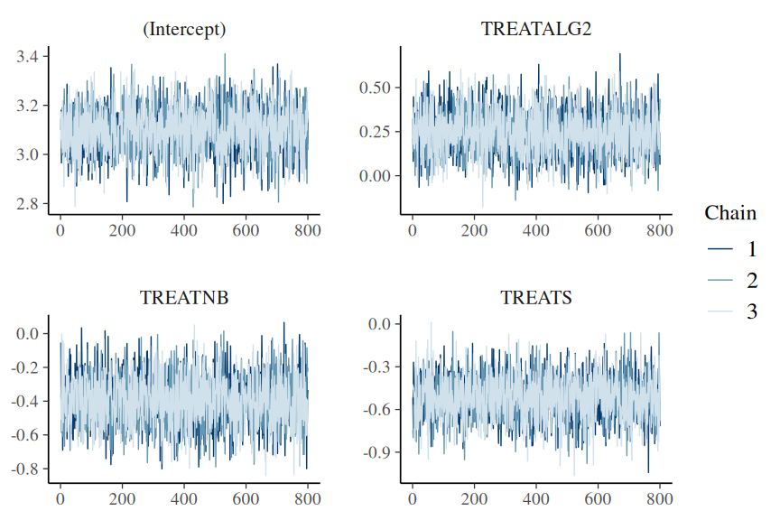

```r
plot(day_rstanarm3, plotfun = "mcmc_trace")
```

The chains appear well mixed and very similar

- acf (auto-correlation function): plots the auto-correlation between successive MCMC sample lags for each parameter and each chain

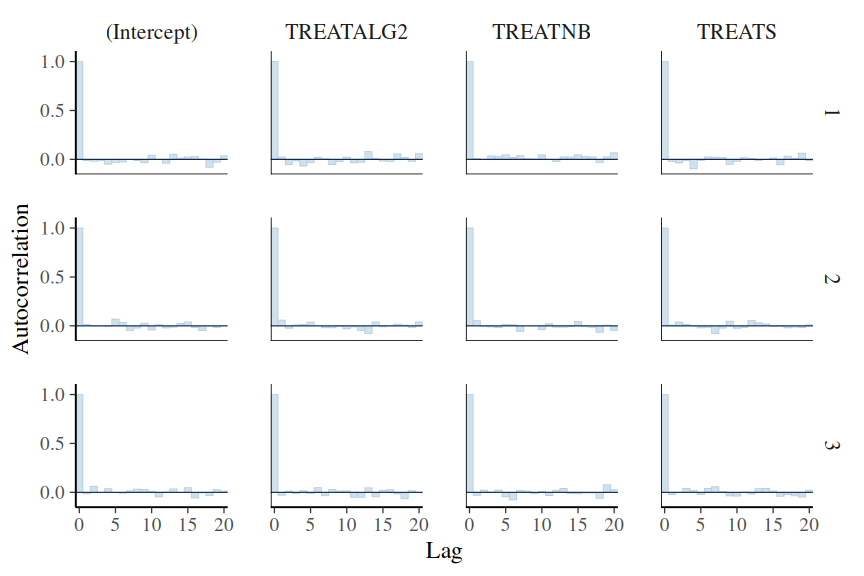

```r
plot(day_rstanarm3, "acf_bar")
```

There is no evidence of auto-correlation in the MCMC samples

- Rhat: Rhat is a measure of convergence between the chains. The closer the values are to 1, the more the chains have converged. Values greater than 1.05 indicate a lack of convergence. There will be an Rhat value for each parameter estimated.

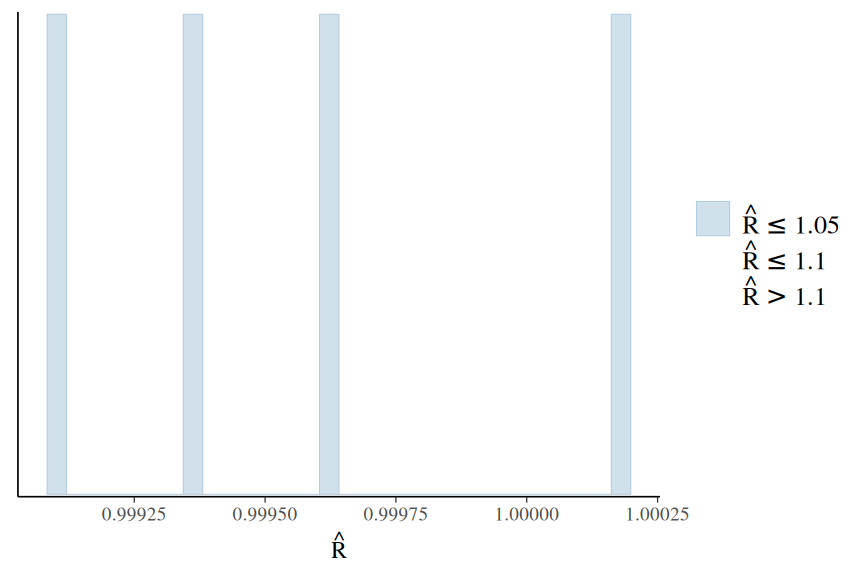

```r
plot(day_rstanarm3, "rhat_hist")
```

All Rhat values are below 1.05, suggesting the chains have converged.

- neff (number of effective samples): the ratio of the number of effective samples (those not rejected by the sampler) to the number of samples provides an indication of the effectiveness (and efficiency) of the MCMC sampler. Ratios that are less than 0.5 for a parameter suggest that the sampler spent considerable time in difficult areas of the sampling domain and rejected more than half of the samples (replacing them with the previous effective sample).

  If the ratios are low, tightening the priors may help.

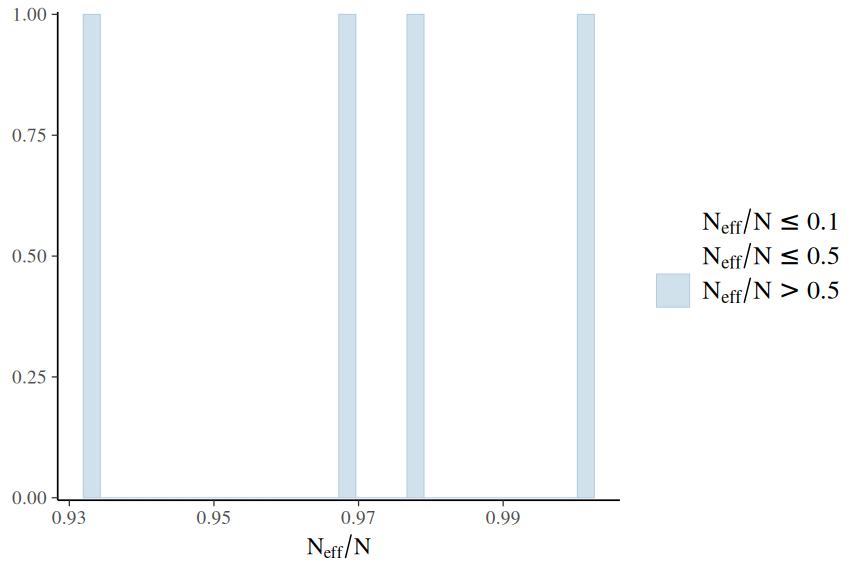

```r
plot(day_rstanarm3, "neff_hist")
```

Ratios all very high.

**More diagnostics**

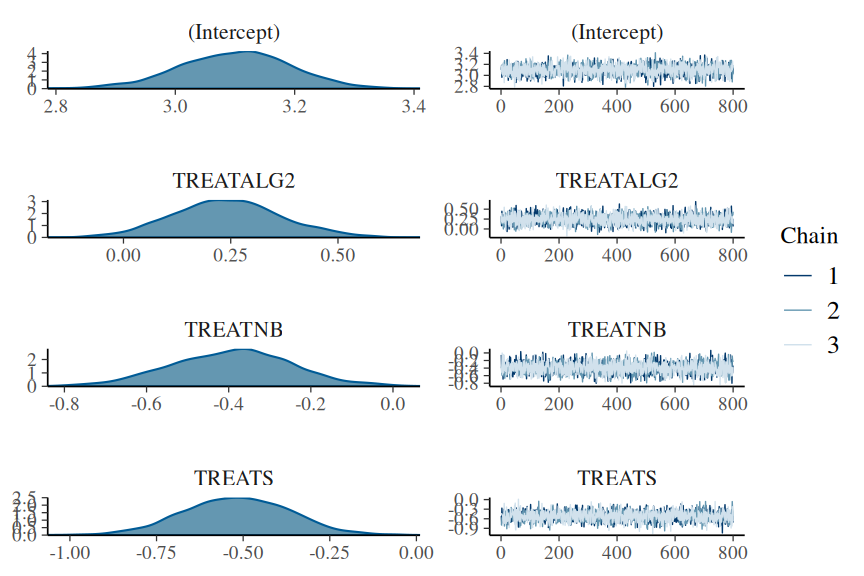

```r
plot(day_rstanarm3, "combo")
```

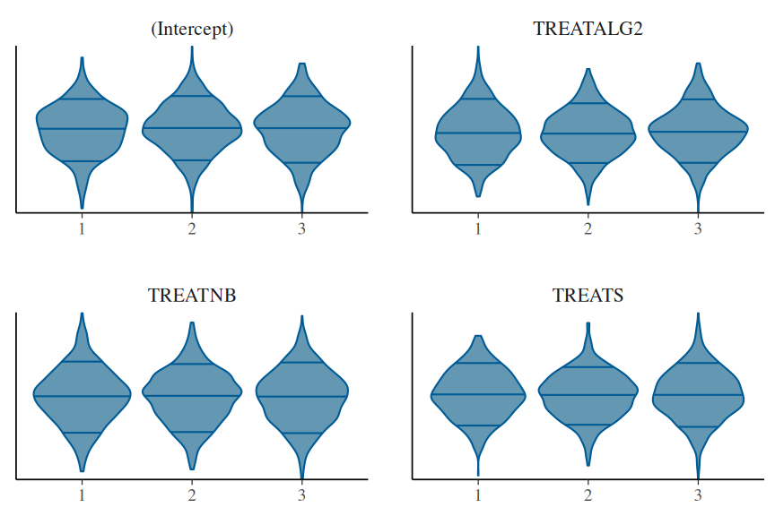

```r
plot(day_rstanarm3, "violin")
```

**stan plots**

The `rstan` package offers a range of MCMC diagnostics. Lets start with the MCMC diagnostics.

Of these, we will focus on:

- stan_trace: this plots the estimates of each parameter over the post-warmup length of each MCMC chain. Each chain is plotted in a different colour, with each parameter in its own facet. Ideally, each **trace** should just look like noise without any discernible drift and each of the traces for a specific parameter should look the same (i.e, should not be displaced above or below any other trace for that parameter).

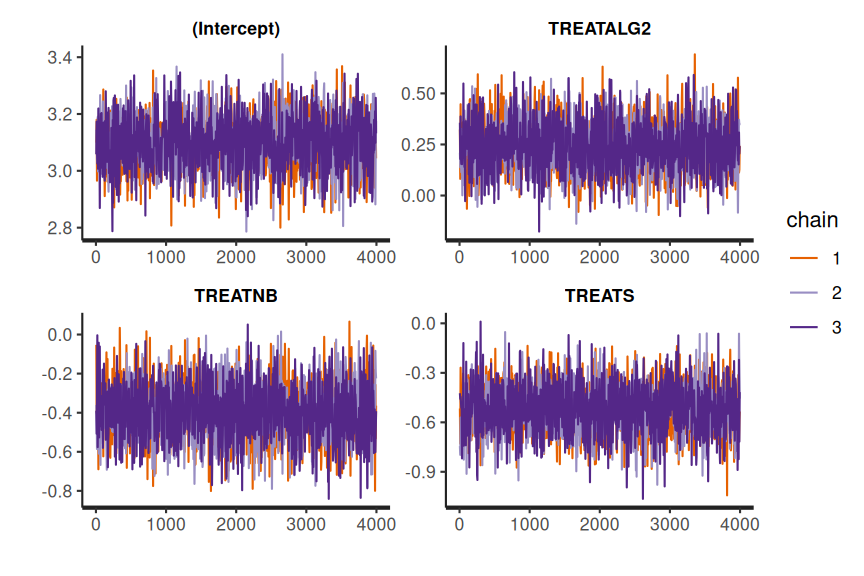

```r
stan_trace(day_rstanarm3)
```

The chains appear well mixed and very similar

- stan_acf (autocorrelation function): plots the autocorrelation between successive MCMC sample lags for each parameter and each chain

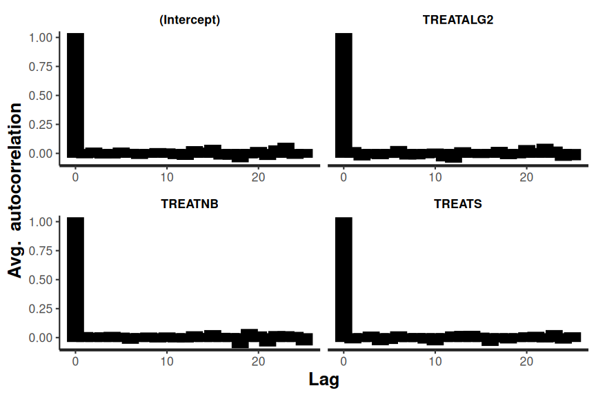

```r
stan_ac(day_rstanarm3)
```

There is no evidence of auto-correlation in the MCMC samples

- stan_rhat: Rhat is a **scale reduction factor** measure of convergence between the chains. The closer the values are to 1, the more the chains have converged. Values greater than 1.05 indicate a lack of convergence. There will be an Rhat value for each parameter estimated.

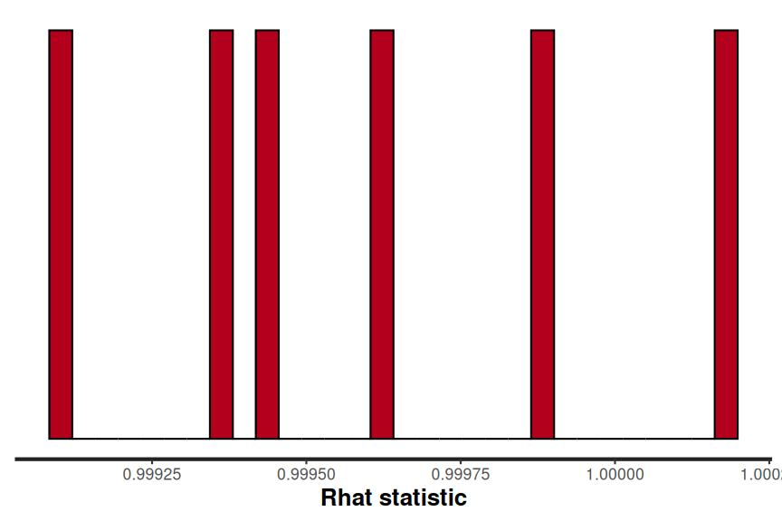

```r
stan_rhat(day_rstanarm3)
```

All Rhat values are below 1.05, suggesting the chains have converged.

- stan_ess (number of effective samples): the ratio of the number of effective samples (those not rejected by the sampler) to the number of samples provides an indication of the effectiveness (and efficiency) of the MCMC sampler. Ratios that are less than 0.5 for a parameter suggest that the sampler spent considerable time in difficult areas of the sampling domain and rejected more than half of the samples (replacing them with the previous effective sample).

  If the ratios are low, tightening the priors may help.

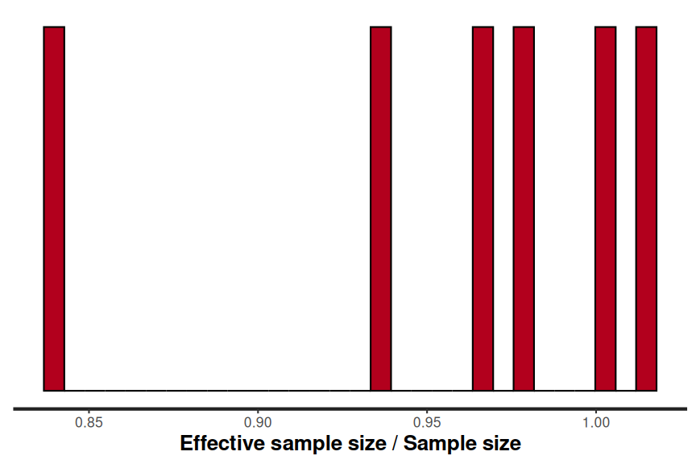

```r
stan_ess(day_rstanarm3)
```

Ratios all very high.

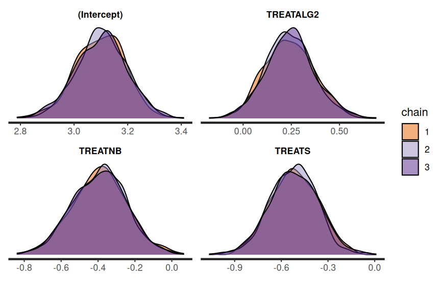

```r
stan_dens(day_rstanarm3, separate_chains = TRUE)
```

**ggmcmc**

The `ggmean` package also has a set of MCMC diagnostic functions. Lets start with the MCMC diagnostics.

Of these, we will focus on:

- ggs_traceplot: this plots the estimates of each parameter over the post-warmup length of each MCMC chain. Each chain is plotted in a different colour, with each parameter in its own facet. Ideally, each **trace** should just look like noise without any discernible drift and each of the traces for a specific parameter should look the same (i.e, should not be displaced above or below any other trace for that parameter).

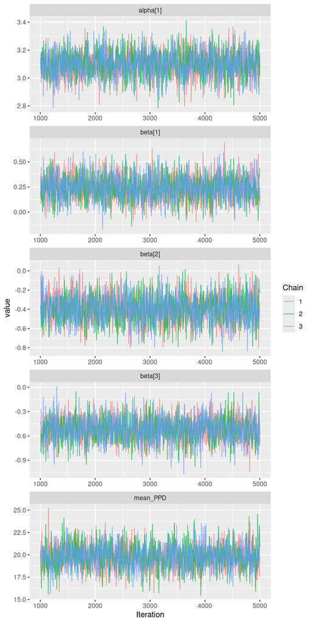

```r
day_ggs <- ggs(day_rstanarm3)
ggs_traceplot(day_ggs)
```

The chains appear well mixed and very similar

- gss_autocorrelation (autocorrelation function): plots the autocorrelation between successive MCMC sample lags for each parameter and each chain

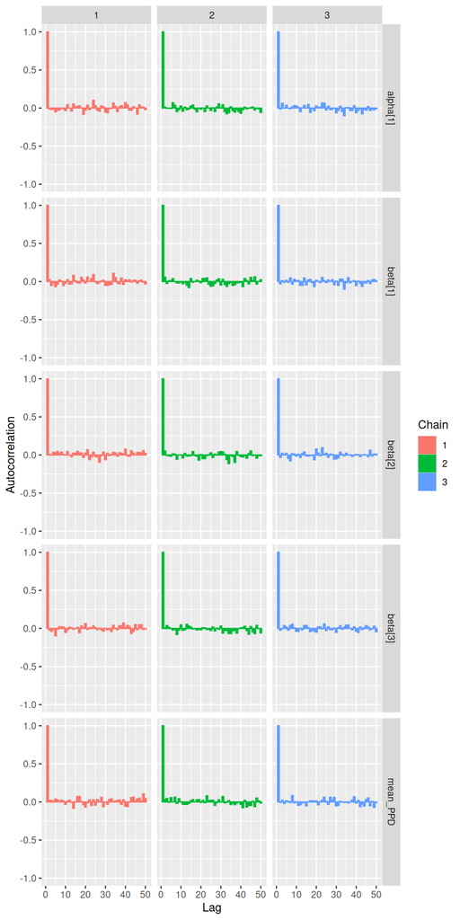

```r
ggs_autocorrelation(day_ggs)
```

There is no evidence of auto-correlation in the MCMC samples

- stan_rhat: Rhat is a **scale reduction factor** measure of convergence between the chains. The closer the values are to 1, the more the chains have converged. Values greater than 1.05 indicate a lack of convergence. There will be an Rhat value for each parameter estimated.

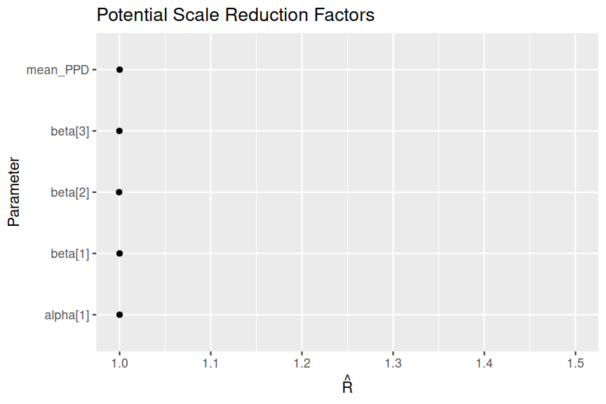

```r
ggs_Rhat(day_ggs)
```

All Rhat values are below 1.05, suggesting the chains have converged.

- stan_ess (number of effective samples): the ratio of the number of effective samples (those not rejected by the sampler) to the number of samples provides an indication of the effectiveness (and efficiency) of the MCMC sampler. Ratios that are less than 0.5 for a parameter suggest that the sampler spent considerable time in difficult areas of the sampling domain and rejected more than half of the samples (replacing them with the previous effective sample).

  If the ratios are low, tightening the priors may help.

[figure not shown]

```r
ggs_effective(day_ggs)
```

**More diagnostics**

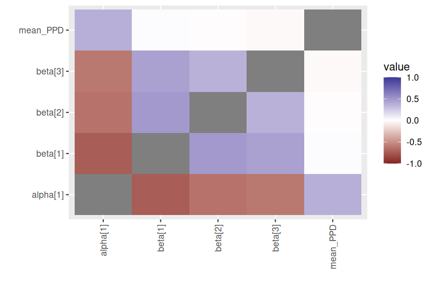

```r
ggs_crosscorrelation(day_ggs)
```

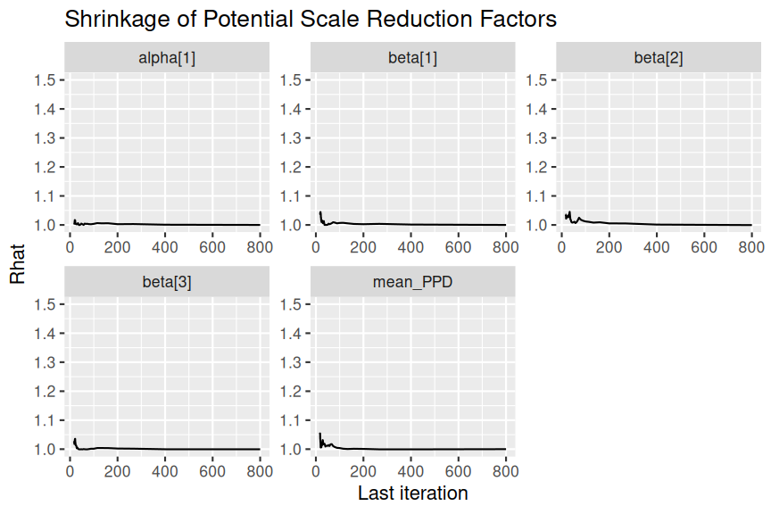

```r
ggs_grb(day_ggs)
```

**brms**

### 6.0.1 stan plots

The `brms` package offers a range of MCMC diagnostics. Lets start with the MCMC diagnostics.

Of these, we will focus on:

- stan_trace: this plots the estimates of each parameter over the post-warmup length of each MCMC chain. Each chain is plotted in a different colour, with each parameter in its own facet. Ideally, each **trace** should just look like noise without any discernible drift and each of the traces for a specific parameter should look the same (i.e, should not be displaced above or below any other trace for that parameter).

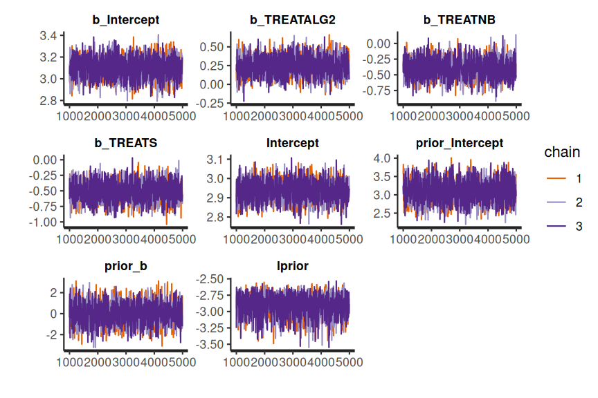

```r
day_brm3$fit |> stan_trace()
```

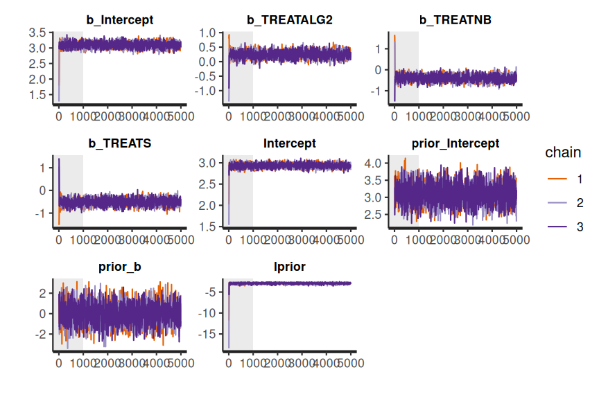

```r
day_brm3$fit |> stan_trace(inc_warmup = TRUE)
```

The chains appear well mixed and very similar

- stan_acf (auto-correlation function): plots the auto-correlation between successive MCMC sample lags for each parameter and each chain

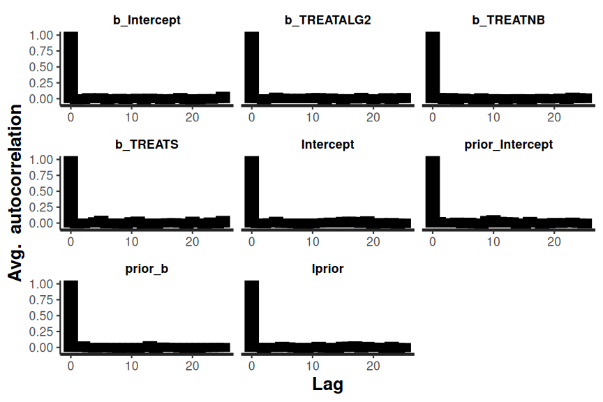

```r
day_brm3$fit |> stan_ac()
```

There is no evidence of auto-correlation in the MCMC samples

- stan_rhat: Rhat is a **scale reduction factor** measure of convergence between the chains. The closer the values are to 1, the more the chains have converged. Values greater than 1.05 indicate a lack of convergence. There will be an Rhat value for each parameter estimated.

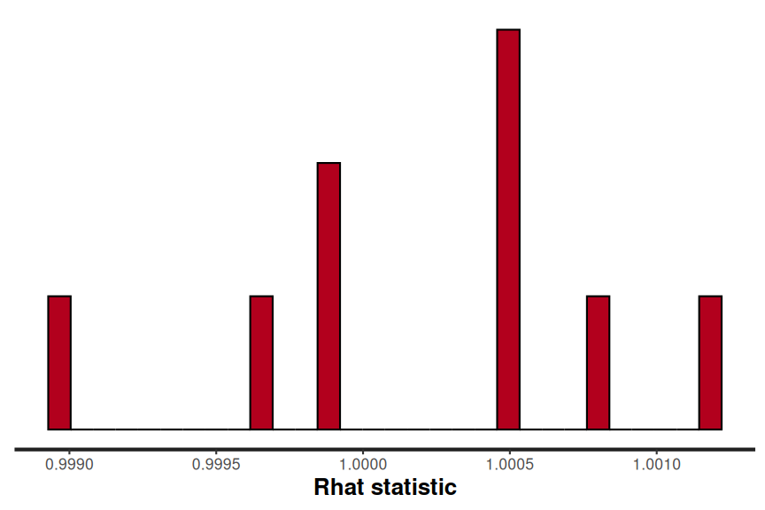

```r
day_brm3$fit |> stan_rhat()
```

All Rhat values are below 1.05, suggesting the chains have converged.

- stan_ess (number of effective samples): the ratio of the number of effective samples (those not rejected by the sampler) to the number of samples provides an indication of the effectiveness (and efficiency) of the MCMC sampler. Ratios that are less than 0.5 for a parameter suggest that the sampler spent considerable time in difficult areas of the sampling domain and rejected more than half of the samples (replacing them with the previous effective sample).

  If the ratios are low, tightening the priors may help.

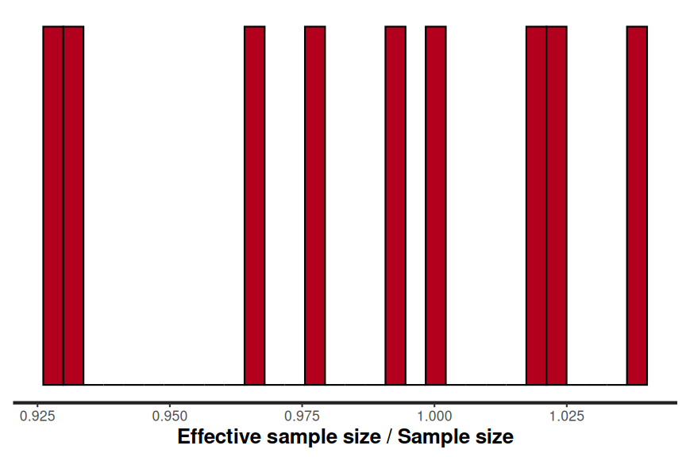

```r
day_brm3$fit |> stan_ess()
```

Ratios all very high.

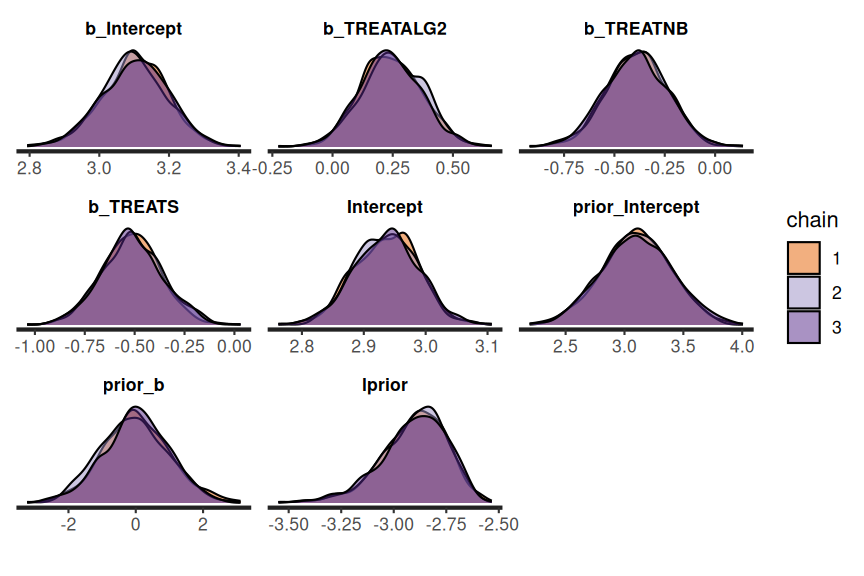

```r
day_brm3$fit |> stan_dens(separate_chains = TRUE)
```

# 7 Model validation

**rstanarm**

**pp check**

Post predictive checks provide additional diagnostics about the fit of the model. Specifically, they provide a comparison between predictions drawn from the model and the observed data used to train the model.

**See list of available diagnostics by name**

```r
available_ppc()
```

```
bayesplot PPC module:
  ppc_bars
  ppc_bars_grouped
  ppc_boxplot
  ppc_dens
  ppc_dens_overlay
  ppc_dens_overlay_grouped
  ppc_dots
  ppc_ecdf_overlay
  ppc_ecdf_overlay_grouped
  ppc_error_binned
  ppc_error_hist
  ppc_error_hist_grouped
  ppc_error_scatter
  ppc_error_scatter_avg
  ppc_error_scatter_avg_grouped
  ppc_error_scatter_avg_vs_x
  ppc_freqpoly
  ppc_freqpoly_grouped
  ppc_hist
  ppc_intervals
  ppc_intervals_grouped
  ppc_km_overlay
  ppc_km_overlay_grouped
  ppc_loo_intervals
  ppc_loo_pit_ecdf
  ppc_loo_pit_overlay
  ppc_loo_pit_qq
  ppc_loo_ribbon
  ppc_pit_ecdf
  ppc_pit_ecdf_grouped
  ppc_ribbon
  ppc_ribbon_grouped
  ppc_rootogram
  ppc_scatter
  ppc_scatter_avg
  ppc_scatter_avg_grouped
  ppc_stat
  ppc_stat_2d
  ppc_stat_freqpoly
  ppc_stat_freqpoly_grouped
  ppc_stat_grouped
  ppc_violin_grouped
```

- dens_overlay: plots the density distribution of the observed data (black line) overlayed on top of 50 density distributions generated from draws from the model (light blue). Ideally, the 50 realisations should be roughly consistent with the observed data.

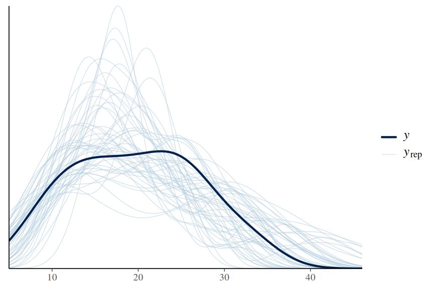

```r
pp_check(day_rstanarm3, plotfun = "dens_overlay")
```

The model draws appear deviate from the observed data.

```r
# pp_check(day_rstanarm3, plotfun='error_scatter_avg')
```

- error_scatter_avg_vs_x: this is similar to a regular residual plot and as such should be interpreted as such. Again, this is not interpretable for binary data.

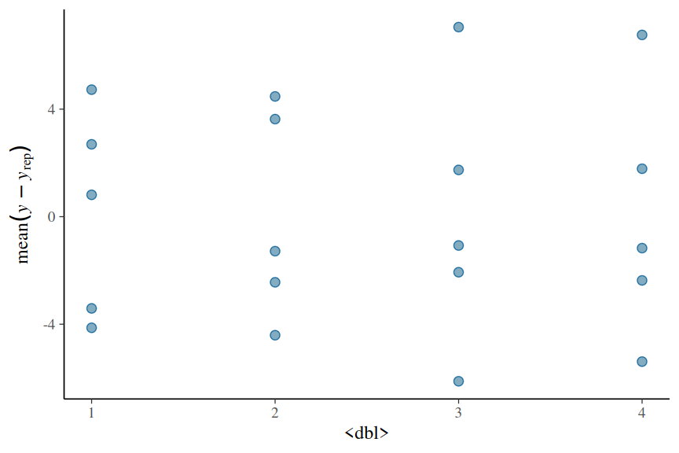

```r
pp_check(day_rstanarm3, x = as.numeric(day$TREAT), plotfun = "error_scatter_avg_vs_x")
```

- intervals: plots the observed data overlayed on top of posterior predictions associated with each level of the predictor. Ideally, the observed data should all fall within the predictive intervals.

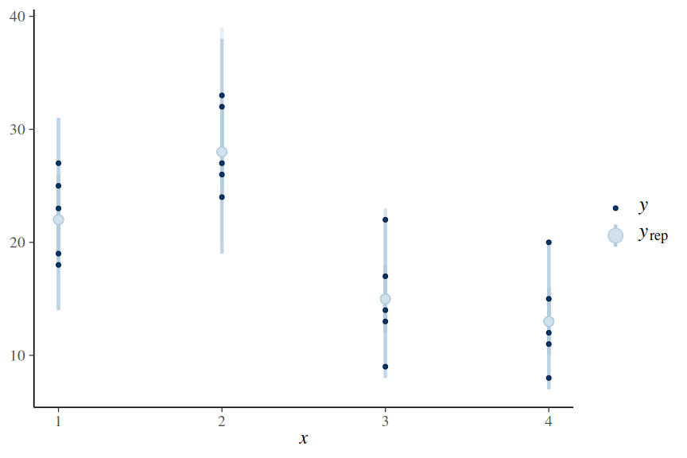

```r
pp_check(day_rstanarm3, x = as.numeric(day$TREAT), plotfun = "intervals")
```

The `shinystan` package allows the full suite of MCMC diagnostics and posterior predictive checks to be accessed via a web interface.

```r
# library(shinystan)
# launch_shinystan(day_rstanarm3)
```

**DHARMa residuals**

DHARMa residuals provide very useful diagnostics. Unfortunately, we cannot directly use the `simulateResiduals()` function to generate the simulated residuals. However, if we are willing to calculate some of the components yourself, we can still obtain the simulated residuals from the fitted stan model.

We need to supply:

- simulated (predicted) responses associated with each observation.
- observed values
- fitted (predicted) responses (averaged) associated with each observation

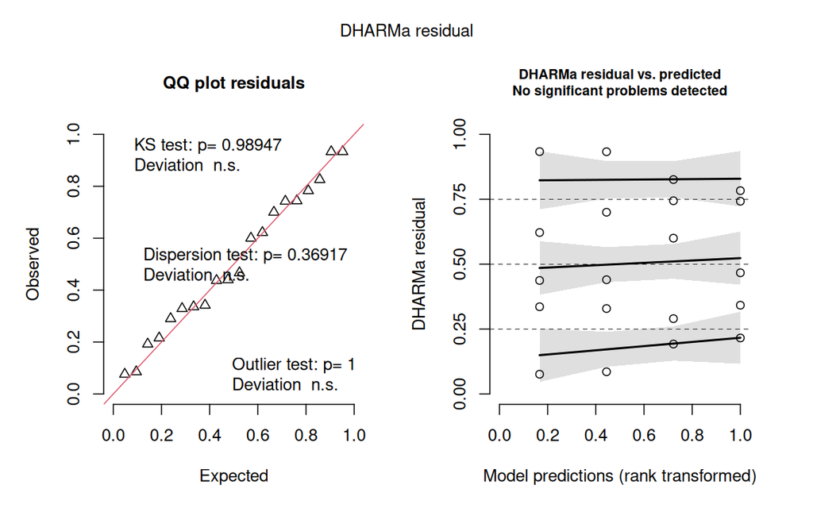

```r
preds <- posterior_predict(day_rstanarm3, ndraws = 250, summary = FALSE)
day_resids <- createDHARMa(
  simulatedResponse = t(preds),
  observedResponse = day$BARNACLE,
  fittedPredictedResponse = apply(preds, 2, median),
  integerResponse = TRUE
)
plot(day_resids)
```

**Conclusions:**

- the simulated residuals DOES NOT suggest any issues with the fitted model

**brms**

**pp check**

Post predictive checks provide additional diagnostics about the fit of the model. Specifically, they provide a comparison between predictions drawn from the model and the observed data used to train the model.

**See list of available diagnostics by name**

```r
available_ppc()
```

```
bayesplot PPC module:
  ppc_bars
  ppc_bars_grouped
  ppc_boxplot
  ppc_dens
  ppc_dens_overlay
  ppc_dens_overlay_grouped
  ppc_dots
  ppc_ecdf_overlay
  ppc_ecdf_overlay_grouped
  ppc_error_binned
  ppc_error_hist
  ppc_error_hist_grouped
  ppc_error_scatter
  ppc_error_scatter_avg
  ppc_error_scatter_avg_grouped
  ppc_error_scatter_avg_vs_x
  ppc_freqpoly
  ppc_freqpoly_grouped
  ppc_hist
  ppc_intervals
  ppc_intervals_grouped
  ppc_km_overlay
  ppc_km_overlay_grouped
  ppc_loo_intervals
  ppc_loo_pit_ecdf
  ppc_loo_pit_overlay
  ppc_loo_pit_qq
  ppc_loo_ribbon
  ppc_pit_ecdf
  ppc_pit_ecdf_grouped
  ppc_ribbon
  ppc_ribbon_grouped
  ppc_rootogram
  ppc_scatter
  ppc_scatter_avg
  ppc_scatter_avg_grouped
  ppc_stat
  ppc_stat_2d
  ppc_stat_freqpoly
  ppc_stat_freqpoly_grouped
  ppc_stat_grouped
  ppc_violin_grouped
```

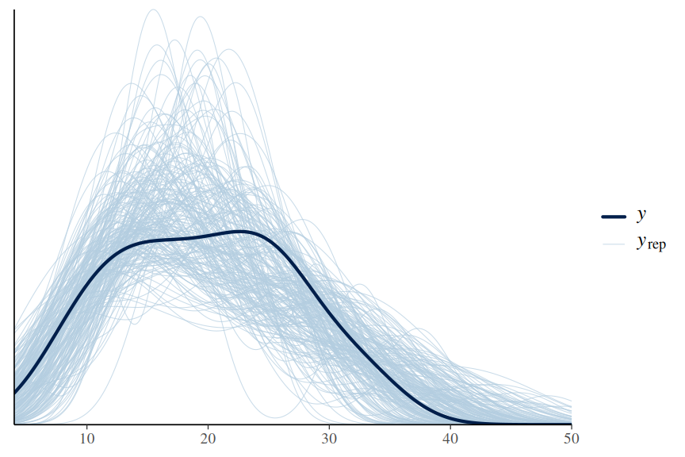

```r
day_brm3 |> pp_check(type = "dens_overlay", ndraws = 200)
```

The model draws appear deviate from the observed data.

```r
# day_brm3 |> pp_check(type = 'error_scatter_avg')
```

- intervals: plots the observed data overlayed on top of posterior predictions associated with each level of the predictor. Ideally, the observed data should all fall within the predictive intervals.

```
Using all posterior draws for ppc type 'intervals' by default.
```

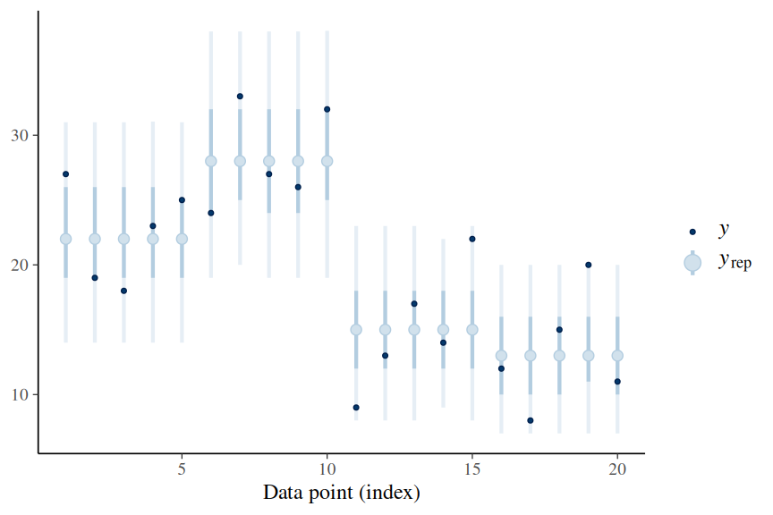

```r
day_brm3 |> pp_check(group = "TREAT", type = "intervals")
```

The `shinystan` package allows the full suite of MCMC diagnostics and posterior predictive checks to be accessed via a web interface.

```r
# library(shinystan)
# launch_shinystan(day_brm3)
```

**DHARMa residuals**

DHARMa residuals provide very useful diagnostics. Unfortunately, we cannot directly use the `simulateResiduals()` function to generate the simulated residuals. However, if we are willing to calculate some of the components yourself, we can still obtain the simulated residuals from the fitted stan model.

We need to supply:

- simulated (predicted) responses associated with each observation.
- observed values
- fitted (predicted) responses (averaged) associated with each observation

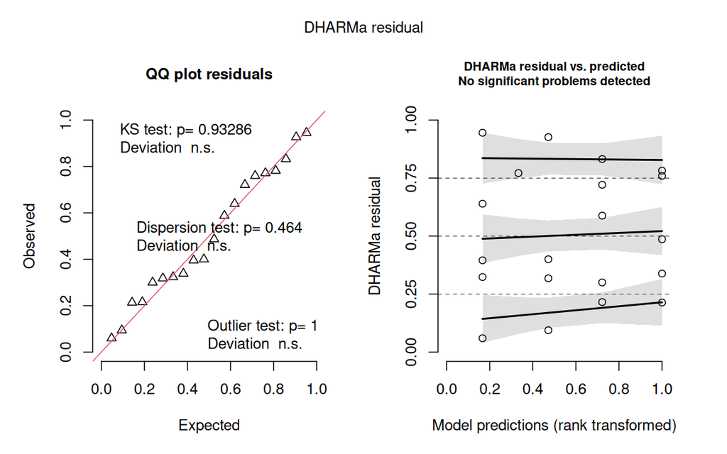

```r
preds <- day_brm3 |> posterior_predict(ndraws = 250, summary = FALSE)
day_resids <- createDHARMa(
  simulatedResponse = t(preds),
  observedResponse = day$BARNACLE,
  fittedPredictedResponse = apply(preds, 2, median),
  integerResponse = TRUE
)
day_resids |> plot()
```

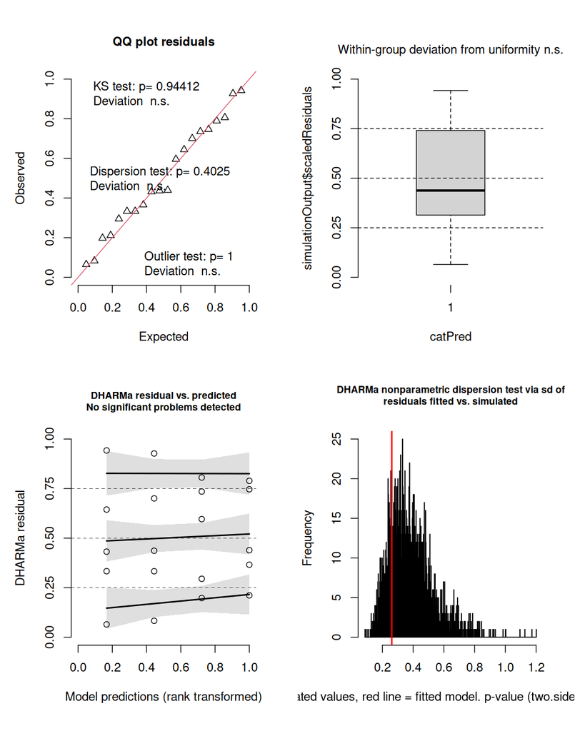

```r
day_resids <- make_brms_dharma_res(day_brm3, integerResponse = TRUE)
wrap_elements(~ testUniformity(day_resids)) +
  wrap_elements(~ plotResiduals(day_resids, form = factor(rep(1, nrow(day))))) +
  wrap_elements(~ plotResiduals(day_resids, quantreg = TRUE)) +
  wrap_elements(~ testDispersion(day_resids))
```

**Conclusions:**

- the simulated residuals DO NOT suggest any issues with the model fit

# 8 Partial effects plots

**rstanarm**

**ggpredict**

```
Data points may overlap. Use the `jitter` argument to add some amount of
  random variation to the location of data points and avoid overplotting.
```

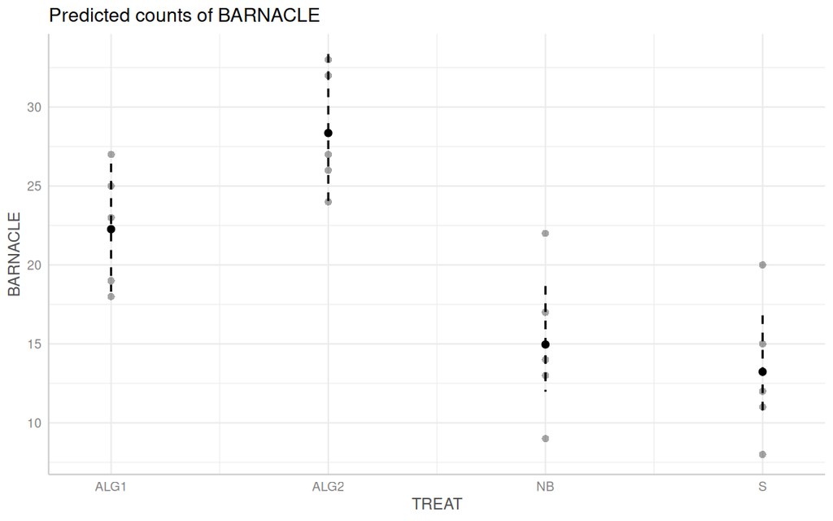

```r
day_rstanarm3 |>
  ggpredict() |>
  plot(show_data = TRUE)
```

**ggemmeans**

```
Data points may overlap. Use the `jitter` argument to add some amount of
  random variation to the location of data points and avoid overplotting.
```

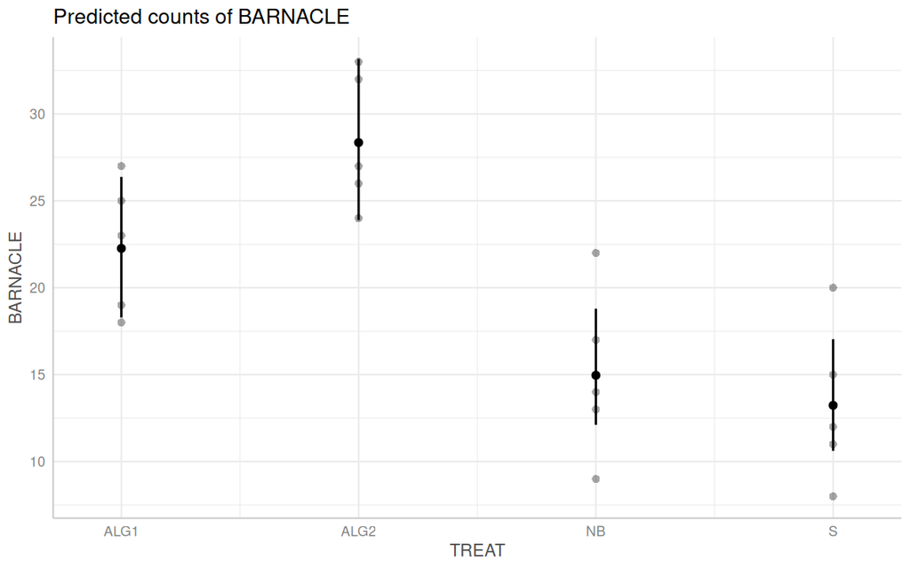

```r
day_rstanarm3 |>
  ggemmeans(~TREAT, type = "fixed") |>
  plot(show_data = TRUE)
```

**epred_draws**

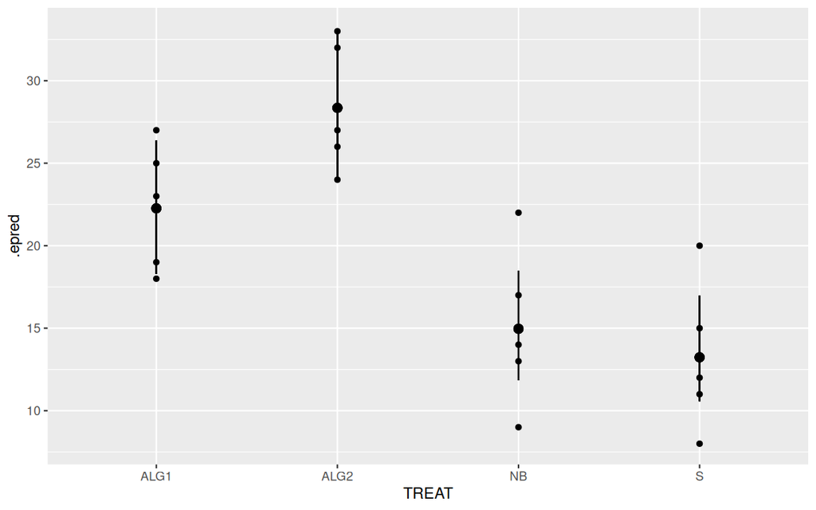

```r
day_rstanarm3 |>
  epred_draws(newdata = day) |>
  median_hdci() |>
  ggplot(aes(x = TREAT, y = .epred)) +
  geom_pointrange(aes(ymin = .lower, ymax = .upper)) +
  geom_line() +
  geom_point(data = day, aes(y = BARNACLE, x = TREAT))
```

**brms**

**conditional_effects**

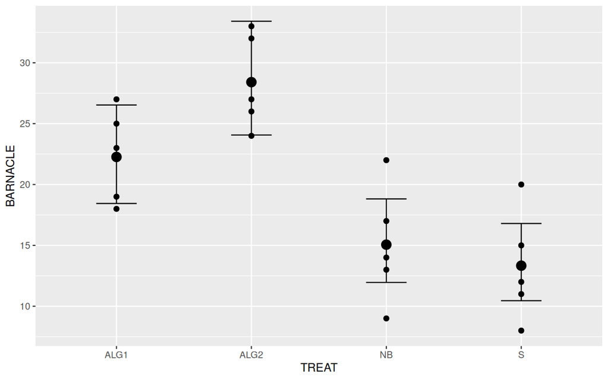

```r
day_brm3 |>
  conditional_effects() |>
  plot(points = TRUE)
```

**ggpredict**

```
Data points may overlap. Use the `jitter` argument to add some amount of
  random variation to the location of data points and avoid overplotting.
```

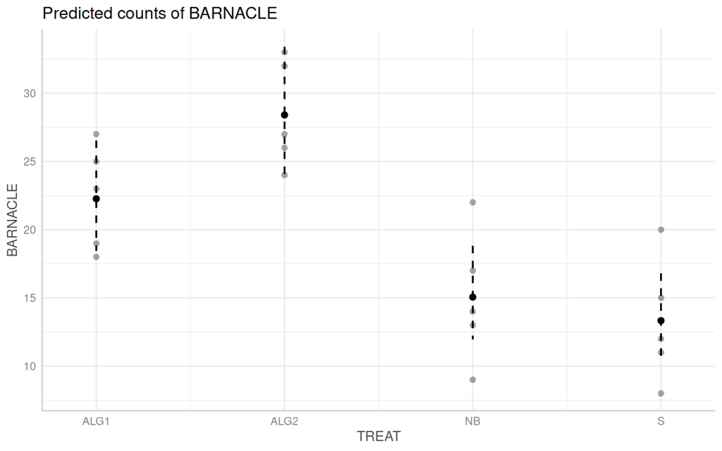

```r
day_brm3 |>
  ggpredict() |>
  plot(show_data = TRUE)
```

**ggemmeans**

```
Data points may overlap. Use the `jitter` argument to add some amount of
  random variation to the location of data points and avoid overplotting.
```

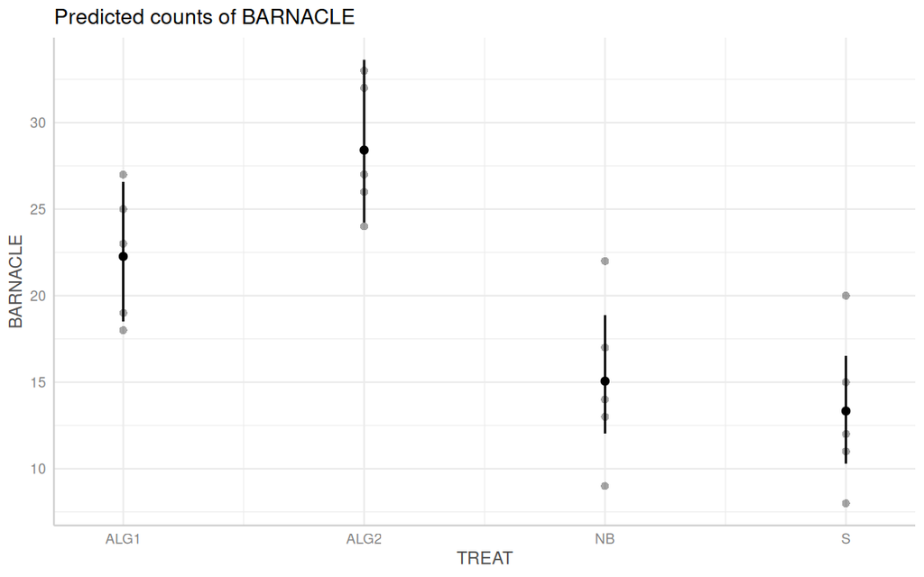

```r
day_brm3 |>
  ggemmeans(~TREAT) |>
  plot(show_data = TRUE)
```

**epred_draws**

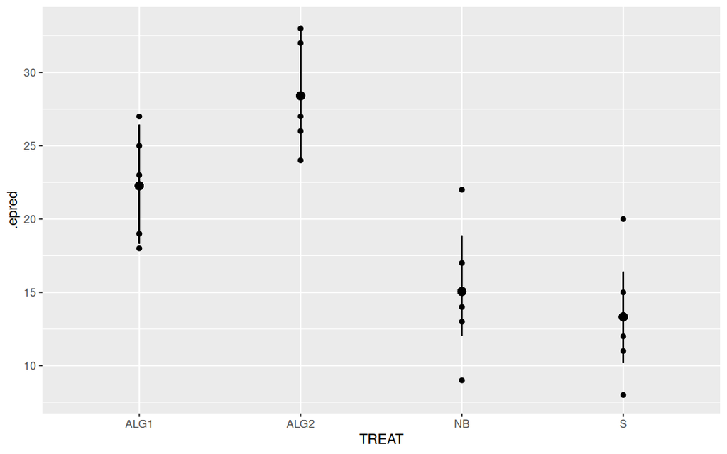

```r
day_brm3 |>
  epred_draws(newdata = day) |>
  median_hdci() |>
  ggplot(aes(x = TREAT, y = .epred)) +
  geom_pointrange(aes(ymin = .lower, ymax = .upper)) +
  geom_line() +
  geom_point(data = day, aes(y = BARNACLE, x = TREAT))
```

# 9 Model investigation

**rstanarm**

**summary**

The `summary()` method generates simple summaries (mean, standard deviation as well as 10, 50 and 90 percentiles).

```r
summary(day_rstanarm3)
```

```
Model Info:
 function:     stan_glm
 family:       poisson [log]
 formula:      BARNACLE ~ TREAT
 algorithm:    sampling
 sample:       2400 (posterior sample size)
 priors:       see help('prior_summary')
 observations: 20
 predictors:   4

Estimates:
              mean   sd   10%   50%   90%
(Intercept)  3.1    0.1  3.0   3.1   3.2
TREATALG2    0.2    0.1  0.1   0.2   0.4
TREATNB     -0.4    0.1 -0.6  -0.4  -0.2
TREATS      -0.5    0.2 -0.7  -0.5  -0.3

Fit Diagnostics:
           mean   sd   10%   50%   90%
mean_PPD 19.8    1.4 18.0  19.8  21.6

The mean_ppd is the sample average posterior predictive distribution of the outcome variable (for details see help('summary.stanreg')).

MCMC diagnostics
              mcse Rhat n_eff
(Intercept)   0.0  1.0  2348
TREATALG2     0.0  1.0  2325
TREATNB       0.0  1.0  2241
TREATS        0.0  1.0  2405
mean_PPD      0.0  1.0  2019
log-posterior 0.0  1.0  2440

For each parameter, mcse is Monte Carlo standard error, n_eff is a crude measure of effective sample size, and Rhat is the potential scale reduction factor on split chains (at convergence Rhat=1).
```

**Conclusions:**

**tidyMCMC**

```r
tidyMCMC(day_rstanarm3$stanfit, estimate.method = "median", conf.int = TRUE, conf.method = "HPDinterval", rhat = TRUE, ess = TRUE)
```

```
# A tibble: 6 × 7
  term          estimate std.error  conf.low conf.high  rhat   ess
  <chr>            <dbl>     <dbl>     <dbl>     <dbl> <dbl> <int>
1 (Intercept)      3.10     0.0931   2.91       3.27   0.999  2348
2 TREATALG2        0.242    0.125   -0.00551    0.489  1.000  2325
3 TREATNB         -0.392    0.146   -0.667     -0.0927 1.00   2241
4 TREATS          -0.518    0.153   -0.829     -0.235  0.999  2405
5 mean_PPD        19.8      1.38    17.0       22.4    1.000  2019
6 log-posterior  -62.1      1.42   -64.9      -60.1    0.999  2440
```

**Conclusions:**

**summarise_draws (posterior)**

```r
day_rstanarm3$stanfit |>
  summarise_draws(
    median,
    HDInterval::hdi,
    rhat, length, ess_bulk, ess_tail
  )
```

```
# A tibble: 6 × 8
  variable       median     lower    upper  rhat length ess_bulk ess_tail
  <chr>           <dbl>     <dbl>    <dbl> <dbl>  <dbl>    <dbl>    <dbl>
1 (Intercept)     3.10    2.91      3.27   0.999   2400    2425.    2411.
2 TREATALG2       0.240  -0.00551   0.489  1.00    2400    2332.    2328.
3 TREATNB        -0.387  -0.667    -0.0927 1.00    2400    2292.    2448.
4 TREATS         -0.519  -0.829    -0.235  1.00    2400    2434.    2036.
5 mean_PPD       19.8    17.0      22.4    1.000   2400    2014.    2273.
6 log-posterior -61.7   -64.9     -60.1    1.000   2400    2445.    2325.
```

We can also alter the CI level.

```r
day_rstanarm3$stanfit |>
  summarise_draws(
    median,
    ~ HDInterval::hdi(.x, credMass = 0.9),
    rhat, length, ess_bulk, ess_tail
  )
```

```
# A tibble: 6 × 8
  variable       median    lower   upper  rhat length ess_bulk ess_tail
  <chr>           <dbl>    <dbl>   <dbl> <dbl>  <dbl>    <dbl>    <dbl>
1 (Intercept)     3.10    2.95     3.26  0.999   2400    2425.    2411.
2 TREATALG2       0.240   0.0434   0.456 1.00    2400    2332.    2328.
3 TREATNB        -0.387  -0.640   -0.165 1.00    2400    2292.    2448.
4 TREATS         -0.519  -0.747   -0.258 1.00    2400    2434.    2036.
5 mean_PPD       19.8    17.4     21.9   1.000   2400    2014.    2273.
6 log-posterior -61.7   -63.9    -60.1   1.000   2400    2445.    2325.
```

Arguably, it would be better to back-transform to the ratio scale

```r
day_rstanarm3$stanfit |>
  summarise_draws(
    ~ median(exp(.x)),
    ~ HDInterval::hdi(exp(.x)),
    rhat, length, ess_bulk, ess_tail
  )
```

```
# A tibble: 6 × 8
  variable   `~median(exp(.x))`    lower    upper  rhat length ess_bulk ess_tail
  <chr>                   <dbl>    <dbl>    <dbl> <dbl>  <dbl>    <dbl>    <dbl>
1 (Intercep…           2.23e+ 1 1.83e+ 1 2.64e+ 1 0.999   2400    2425.    2411.
2 TREATALG2            1.27e+ 0 9.92e- 1 1.63e+ 0 1.00    2400    2332.    2328.
3 TREATNB              6.79e- 1 4.84e- 1 8.70e- 1 1.00    2400    2292.    2448.
4 TREATS               5.95e- 1 4.22e- 1 7.72e- 1 1.00    2400    2434.    2036.
5 mean_PPD             3.97e+ 8 1.03e+ 7 4.17e+ 9 1.000   2400    2014.    2273.
6 log-poste…           1.56e-27 1.13e-31 5.67e-27 1.000   2400    2445.    2325.
```

**as_draws_df (posteriors)**

```r
day_rstanarm3$stanfit |> as_draws_df()
```

```
# A draws_df: 800 iterations, 3 chains, and 6 variables
   (Intercept) TREATALG2 TREATNB TREATS mean_PPD log-posterior
1          3.1     0.323  -0.053  -0.52       20           -65
2          3.2     0.082  -0.402  -0.73       18           -62
3          3.0     0.447  -0.296  -0.27       22           -62
4          3.1     0.180  -0.346  -0.43       21           -61
5          3.1     0.353  -0.248  -0.70       20           -63
6          3.2     0.185  -0.343  -0.61       23           -61
7          3.2     0.111  -0.689  -0.74       19           -63
8          3.2     0.088  -0.475  -0.72       19           -61
9          3.0     0.354  -0.276  -0.55       19           -61
10         3.0     0.359  -0.181  -0.30       20           -62
# ... with 2390 more draws
# ... hidden reserved variables {'.chain', '.iteration', '.draw'}
```

```r
day_rstanarm3$stanfit |>
  as_draws_df() |>
  summarise_draws(
    median,
    ~ HDInterval::hdi(.x),
    rhat,
    length,
    ess_bulk, ess_tail
  )
```

```
# A tibble: 6 × 8
  variable       median     lower    upper  rhat length ess_bulk ess_tail
  <chr>           <dbl>     <dbl>    <dbl> <dbl>  <dbl>    <dbl>    <dbl>
1 (Intercept)     3.10    2.91      3.27   0.999   2400    2425.    2411.
2 TREATALG2       0.240  -0.00551   0.489  1.00    2400    2332.    2328.
3 TREATNB        -0.387  -0.667    -0.0927 1.00    2400    2292.    2448.
4 TREATS         -0.519  -0.829    -0.235  1.00    2400    2434.    2036.
5 mean_PPD       19.8    17.0      22.4    1.000   2400    2014.    2273.
6 log-posterior -61.7   -64.9     -60.1    1.000   2400    2445.    2325.
```

```r
day_rstanarm3$stanfit |>
  as_draws_df() |>
  exp() |>
  summarise_draws(
    median,
    ~ HDInterval::hdi(.x),
    rhat,
    length,
    ess_bulk, ess_tail
  )
```

```
# A tibble: 6 × 8
  variable        median    lower    upper  rhat length ess_bulk ess_tail
  <chr>            <dbl>    <dbl>    <dbl> <dbl>  <dbl>    <dbl>    <dbl>
1 (Intercept)   2.23e+ 1 1.83e+ 1 2.64e+ 1 0.999   2400    2425.    2411.
2 TREATALG2     1.27e+ 0 9.92e- 1 1.63e+ 0 1.00    2400    2332.    2328.
3 TREATNB       6.79e- 1 4.84e- 1 8.70e- 1 1.00    2400    2292.    2448.
4 TREATS        5.95e- 1 4.22e- 1 7.72e- 1 1.00    2400    2434.    2036.
5 mean_PPD      3.97e+ 8 1.03e+ 7 4.17e+ 9 1.00    2400    2014.    2273.
6 log-posterior 1.56e-27 1.13e-31 5.67e-27 1.00    2400    2445.    2325.
```

**gather_draws**

```r
day_rstanarm3 |> get_variables()
```

```
 [1] "(Intercept)"   "TREATALG2"     "TREATNB"       "TREATS"
 [5] "accept_stat__" "stepsize__"    "treedepth__"   "n_leapfrog__"
 [9] "divergent__"   "energy__"
```

```r
day_draw <- day_rstanarm3 |> gather_draws(`.Intercept.*|.*TREAT.*`, regex = TRUE)
day_draw
```

```
# A tibble: 9,600 × 5
# Groups:   .variable [4]
   .chain .iteration .draw .variable   .value
    <int>      <int> <int> <chr>        <dbl>
 1      1          1     1 (Intercept)   3.10
 2      1          2     2 (Intercept)   3.18
 3      1          3     3 (Intercept)   2.97
 4      1          4     4 (Intercept)   3.15
 5      1          5     5 (Intercept)   3.06
 6      1          6     6 (Intercept)   3.19
 7      1          7     7 (Intercept)   3.19
 8      1          8     8 (Intercept)   3.19
 9      1          9     9 (Intercept)   3.00
10      1         10    10 (Intercept)   3.02
# ℹ 9,590 more rows
```